# Linear Regression Case Study

Arjun Pawar

10/04/2022

```r
setwd ("/Users/arjun/Documents/Data course")
require("readxl")
require("Hmisc")
require("dplyr")
```

Data Cleaning & Preparation

```r
df <- read_excel("Linear Regression Case.xlsx", sheet = "customer_dbase")
describe (df)
```

```
## df
##
##  132  Variables      5000  Observations
## --------------------------------------------------------------------------------
## custid
##        n  missing distinct
##     5000        0     5000
##
## lowest : 0002-GTOKLU-YVY 0003-RLTRGE-IW2 0003-UTGKPR-PRU 0008-ZIQQOT-SGB 0012-CIVYLF-839
## highest: 9991-FCIBKT-W29 9992-FSFJPL-5D6 9997-QIXKNU-54A 9998-ZGHXLK-EOT 9999-EGLHVE-19G
## --------------------------------------------------------------------------------
## region
##        n  missing distinct     Info     Mean      Gmd
##     5000        0        5     0.96    3.001    1.609
##
## lowest : 1 2 3 4 5, highest: 1 2 3 4 5
##
## Value          1     2     3     4     5
## Frequency   1009   995  1003   966  1027
## Proportion 0.202 0.199 0.201 0.193 0.205
## --------------------------------------------------------------------------------
## townsize
##        n  missing distinct     Info     Mean      Gmd
##     4998        2        5    0.953    2.687    1.601
##
## lowest : 1 2 3 4 5, highest: 1 2 3 4 5
##
## Value          1     2     3     4     5
## Frequency   1436  1048   907   857   750
## Proportion 0.287 0.210 0.181 0.171 0.150
## --------------------------------------------------------------------------------
## gender
##        n  missing distinct     Info      Sum     Mean      Gmd
##     5000        0        2     0.75     2518   0.5036   0.5001
##
## --------------------------------------------------------------------------------
## age
##        n  missing distinct     Info     Mean      Gmd      .05      .10
##     5000        0       62        1    47.03    20.51       20       23
##      .25      .50      .75      .90      .95
```

[output cut: 974 more lines]

```
## response_01
##        n  missing distinct     Info      Sum     Mean      Gmd
##     5000        0        2     0.23      418   0.0836   0.1533
##
## --------------------------------------------------------------------------------
## response_02
##        n  missing distinct     Info      Sum     Mean      Gmd
##     5000        0        2    0.339      649   0.1298   0.2259
##
## --------------------------------------------------------------------------------
## response_03
##        n  missing distinct     Info      Sum     Mean      Gmd
##     5000        0        2    0.276      513   0.1026   0.1842
##
## --------------------------------------------------------------------------------
```

```r
mystats <- function(x){

  n = length(x)
  nmiss = sum(is.na(x))
  nmiss_pct = mean(is.na(x))
  sum = sum(x, na.rm=T)
  mean = mean(x, na.rm=T)
  median = quantile(x, p=0.5, na.rm=T)
  std = sd(x, na.rm=T)
  var = var(x, na.rm=T)
  range = max(x, na.rm=T)-min(x, na.rm=T)
  pctl = quantile(x, p=c(0, 0.01, 0.05,0.1,0.25,0.5, 0.75,0.9,0.95,0.99,1), na.rm=T)
  return(c(N=n, Nmiss =nmiss, Nmiss_pct = nmiss_pct, sum=sum, avg=mean, median=median, std=std, var=var, range=range, pctl=pctl))
}
```

Treating outliers for the numerical features

```r
numeric_features = names(df)[sapply(df, FUN=is.numeric)]
summary_stats = t(apply(df[numeric_features], 2, FUN = mystats))
write.csv(summary_stats, file = "stats.csv")

outlier_treat <- function(x)
{
  UC1 = quantile(x, p=0.99,na.rm=T)
  LC1 = quantile(x, p=0.01,na.rm=T)
  x=ifelse(x>UC1, UC1, x)
  x=ifelse(x<LC1, LC1, x)
  return(x)
}

outlier_treated_df = data.frame(apply(df[numeric_features], 2,
                                      FUN=outlier_treat))

summary_stats1 = t(apply(outlier_treated_df, 2, FUN=mystats))

colnames(df)[!(colnames(df) %in% colnames(outlier_treated_df))]
```

```
## [1] "custid"     "birthmonth"
```

Finding features with missing values

```r
#MISSING VALUE TREATMENT

# The features with missing values are:
summary_df = data.frame(summary_stats1)
misscols = summary_df[summary_df$Nmiss_pct > 0,]
rownames(misscols)
```

```
##  [1] "townsize"    "lncreddebt"  "lnothdebt"   "commutetime" "longten"
##  [6] "lnlongten"   "lntollmon"   "lntollten"   "lnequipmon"  "lnequipten"
## [11] "lncardmon"   "cardten"     "lncardten"   "lnwiremon"   "lnwireten"
```

```r
#These are the features with missing values (15 total)
```

Some features were treated with median value imputation

```r
#Treating some of the numeric variables with median value imputation

outlier_treated_df$townsize[is.na(outlier_treated_df$townsize)] =
  round(median(outlier_treated_df$townsize, na.rm = T))

outlier_treated_df$cardten[is.na(outlier_treated_df$cardten)] =
  round(median(outlier_treated_df$cardten, na.rm = T))

outlier_treated_df$commutetime[is.na(outlier_treated_df$commutetime)] =
  round(median(outlier_treated_df$commutetime, na.rm = T))

outlier_treated_df$longten[is.na(outlier_treated_df$longten)] =
  (median(outlier_treated_df$longten, na.rm = T))


summary_stats1 = t(apply(outlier_treated_df, 2, FUN=mystats))
summary_df = data.frame(summary_stats1)
misscols = summary_df[summary_df$Nmiss_pct > 0,]
rownames(misscols)
```

```
##  [1] "lncreddebt" "lnothdebt"  "lnlongten"  "lntollmon"  "lntollten"
##  [6] "lnequipmon" "lnequipten" "lncardmon"  "lncardten"  "lnwiremon"
## [11] "lnwireten"
```

```r
#Checking that only 11 features have missing values now
```

Treating logarithmic features with missing values.

Using strategy of transforming a variable x into logarithmic by taking ln(x+1) instead of ln(x) as x can have 0 values.

```r
#NOW ONLY LOGARITHMIC VARIABLES ARE LEFT TO TREAT


lncols_to_change =  rownames  (misscols)

ln_cleaning = function (x)
{
   x <- ifelse(is.na(x), 0 , log(exp(x)+1))
}

updatedcols = data.frame(apply(outlier_treated_df[lncols_to_change], 2, FUN=ln_cleaning))

outlier_treated_df$lncardmon = updatedcols$lncardmon
outlier_treated_df$lncreddebt = updatedcols$lncreddebt
outlier_treated_df$lnothdebt = updatedcols$lnothdebt
outlier_treated_df$lnlongten = updatedcols$lnlongten
outlier_treated_df$lntollmon = updatedcols$lntollmon
outlier_treated_df$lntollten = updatedcols$lntollten
outlier_treated_df$lnequipmon = updatedcols$lnequipmon
outlier_treated_df$lnequipten = updatedcols$lnequipten
outlier_treated_df$lncardten = updatedcols$lncardten
outlier_treated_df$lnwiremon = updatedcols$lnwiremon
outlier_treated_df$lnwireten = updatedcols$lnwireten

#Checking that 0 features have missing values now
summary_stats1 = t(apply(outlier_treated_df, 2, FUN=mystats))
summary_df = data.frame(summary_stats1)
misscols = summary_df[summary_df$Nmiss_pct > 0,]
rownames(misscols)
```

```
## character(0)
```

```r
#All numeric values have thus been cleaned
```

All numeric values have thus been cleaned.  
Now looking at the categorical variables.

```r
#Finally, we convert the birth-month to a numeric factor

outlier_treated_df$monthno = match(df$birthmonth ,month.name)
```

Preparing the response variable Y as asked by business objective:

```r
#Constructing our Y variable (what we need to predict)
outlier_treated_df$TotalSpend = outlier_treated_df$cardspent+
                              outlier_treated_df$card2spent

finaldf = outlier_treated_df

#Removing the constituent components of our Y variable from dataset

finaldf$cardspent = NULL
finaldf$card2spent = NULL
```

This finaldf has 130 features as the CustID was removed from data (not needed) Birthmonth was added to the dataframe by converting it to numeric 2 columns were replaced by 1 (TotalSpend)

Now checking distribution of this response variable.

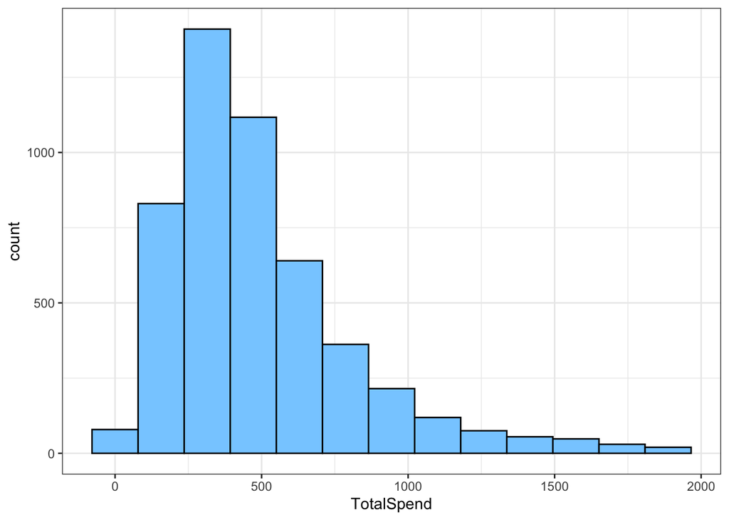

```r
YVarHist <- ggplot(data = finaldf) + aes(TotalSpend) +
  geom_histogram(bins = 13,fill = "skyblue1",color = "black") +
  theme_bw()
plot(YVarHist)
```

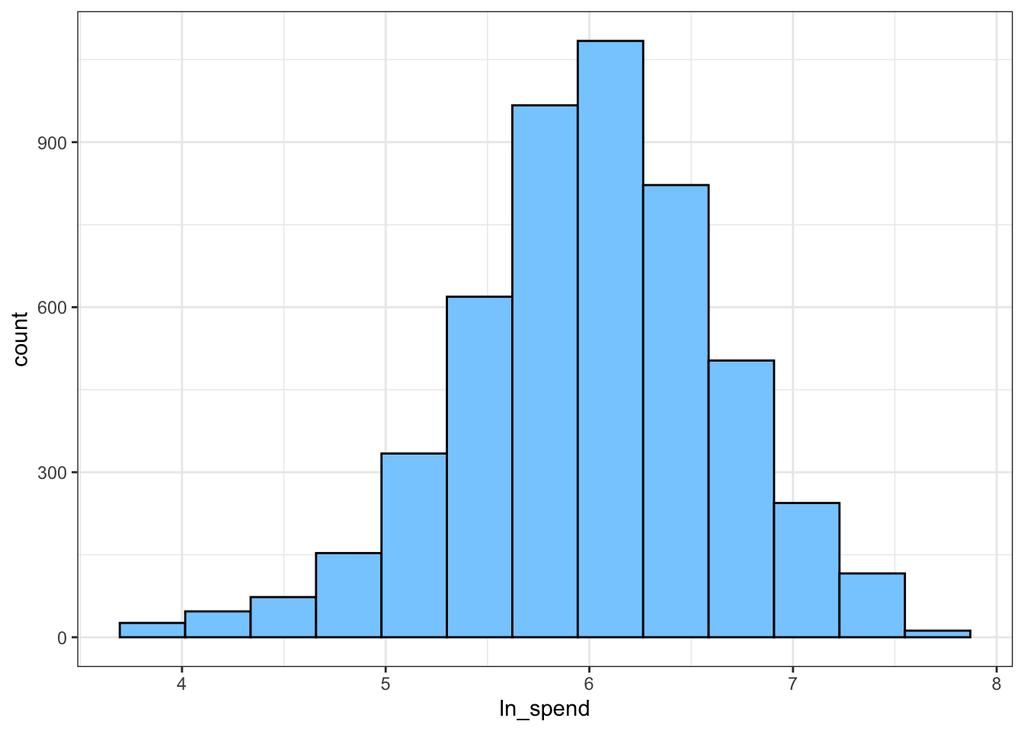

```r
# convert TotalSpend to ln TotalSpend
finaldf$ln_spend <- log(finaldf$TotalSpend)


YVarHist <- ggplot(data = finaldf) + aes(ln_spend) +
  geom_histogram(bins = 13,fill = "skyblue1",color = "black") +
  theme_bw()
plot(YVarHist)
```

```r
#This distribution is more 'normal'

finaldf2 = finaldf
finaldf2$TotalSpend = NULL

#Our new y variable is now ln_spend
```

The response variable is now transformed logarithmically.

Now checking correlation between predictor variables:

```r
cor_mat<-data.frame(cor(finaldf2))
write.csv(cor_mat, "cor_mat.csv")
```

Analysis of correlation matrix

Observation 1 - Some of the variables have also been ‘binned’ so the binned feature has high correlation with the actual variable,

These include: age and agecat; ed and edcat; employ and empcat; income and inccat; spoused and spousedcat; address and addresscat; carvalue and carcatvalue; commute and commutecat; cardtenure and cardtenurecat;card2tenure and card2tenurecat;

Observation 2 - The log-transformed variables are obviously in high corrrelation with the original-state variables. Only one of these needs to be kept. We need to drop 1 feature from each pair wrt these two observations

```r
# Removing those variables which already have a corresponding binned feature

finaldf2$age = NULL
finaldf2$ed = NULL
finaldf2$employ = NULL
finaldf2$income = NULL
finaldf2$spoused = NULL
finaldf2$address = NULL
finaldf2$carvalue = NULL
finaldf2$commute = NULL
finaldf2$cardtenure = NULL
finaldf2$card2tenure = NULL

# Removing those variables which already have a corresponding log-transformed feature

finaldf2$cardmon = NULL
finaldf2$creddebt = NULL
finaldf2$othdebt = NULL
finaldf2$longten =  NULL
finaldf2$tollmon =  NULL
finaldf2$tollten =  NULL
finaldf2$equipmon =  NULL
finaldf2$equipten =  NULL
finaldf2$cardten =  NULL
finaldf2$wiremon =  NULL
finaldf2$wireten =  NULL
finaldf2$longmon =  NULL

cor_mat2<-data.frame(cor(finaldf2))
write.csv(cor_mat2, "cor_mat_updated.csv")
```

Upon analysis of this updated correlation matrix, we realise that number of freshwater fish is strongly correlated to total pets as total pets is defined using freshwater fish. So we will get rid of freshwater fish.

```r
finaldf2$pets_freshfish  =  NULL

# The dataframe is now clean and ready for modelling.
```

The dataframe is now clean and ready for modelling.

Dividing the dataset:

```r
# Dividing the dataset into train & test

rows_in_train <- sample(1:nrow(finaldf2), floor (nrow(finaldf2)*0.7) )

train <- finaldf2[rows_in_train,]
test  <- finaldf2[-rows_in_train,]

nrow(finaldf2)
```

```
## [1] 5000
```

```r
nrow(train)
```

```
## [1] 3500
```

```r
nrow(test)
```

```
## [1] 1500
```

Training process

```r
# Training the model

fit<- lm(ln_spend~., data=train)
summary(fit) #0.6485
```

```
##
## Call:
## lm(formula = ln_spend ~ ., data = train)
##
## Residuals:
##      Min       1Q   Median       3Q      Max
## -1.30693 -0.26576 -0.01338  0.24137  1.41422
##
## Coefficients:
##                     Estimate Std. Error t value Pr(>|t|)
## (Intercept)        4.1531096  0.1458469  28.476  < 2e-16 ***
## region             0.0095039  0.0051020   1.863   0.0626 .
## townsize           0.0047997  0.0062411   0.769   0.4419
## gender            -0.0526698  0.0133330  -3.950 7.96e-05 ***
## agecat             0.0008605  0.0121787   0.071   0.9437
## edcat             -0.0123404  0.0076478  -1.614   0.1067
## jobcat            -0.0083841  0.0044552  -1.882   0.0599 .
## union              0.0233254  0.0185785   1.256   0.2094
## empcat             0.0016980  0.0091976   0.185   0.8535
## retire             0.0351336  0.0311293   1.129   0.2591
## lninc              0.2975044  0.0421038   7.066 1.93e-12 ***
## inccat             0.0129428  0.0199561   0.649   0.5167
## debtinc            0.0003674  0.0026862   0.137   0.8912
## lncreddebt         0.0118680  0.0211295   0.562   0.5744
## lnothdebt         -0.0043643  0.0272454  -0.160   0.8727
## default            0.0065865  0.0189814   0.347   0.7286
## jobsat            -0.0085471  0.0057066  -1.498   0.1343
## marital           -0.0293655  0.0365378  -0.804   0.4216
## spousedcat         0.0073099  0.0092800   0.788   0.4309
## reside             0.0049092  0.0071882   0.683   0.4947
## pets              -0.0011909  0.0022004  -0.541   0.5884
## pets_cats          0.0160740  0.0083782   1.919   0.0551 .
## pets_dogs         -0.0057148  0.0090757  -0.630   0.5289
## pets_birds         0.0042891  0.0147568   0.291   0.7713
## pets_reptiles      0.0583096  0.0239644   2.433   0.0150 *
## pets_small         0.0032974  0.0139200   0.237   0.8128
## pets_saltfish      0.0205518  0.0339065   0.606   0.5445
## homeown            0.0162504  0.0145501   1.117   0.2641
## hometype           0.0106614  0.0072933   1.462   0.1439
## addresscat        -0.0019814  0.0102134  -0.194   0.8462
```

[output cut: 68 more lines]

```
## ownpc              0.0175517  0.0185917   0.944   0.3452
## ownipod           -0.0252913  0.0161159  -1.569   0.1167
## owngame            0.0043590  0.0163446   0.267   0.7897
## ownfax            -0.0033166  0.0226899  -0.146   0.8838
## news               0.0136256  0.0167871   0.812   0.4170
## response_01       -0.0025626  0.0244717  -0.105   0.9166
## response_02        0.0116745  0.0199177   0.586   0.5578
## response_03        0.0565468  0.0225145   2.512   0.0121 *
## monthno            0.0026154  0.0019321   1.354   0.1759
## ---
## Signif. codes:  0 '***' 0.001 '**' 0.01 '*' 0.05 '.' 0.1 ' ' 1
##
## Residual standard error: 0.3875 on 3393 degrees of freedom
## Multiple R-squared:  0.6552, Adjusted R-squared:  0.6444
## F-statistic: 60.82 on 106 and 3393 DF,  p-value: < 2.2e-16
```

Now performing some manual trial-and-error:

```r
# Upon manually reducing some features we arrive at the following:
fit1 <- lm(ln_spend~ gender + lninc + addresscat + commutewalk + card
             + card2 + carditems + card2items +
             internet + response_03
           +owngame, data=train)
summary(fit1)
```

```
##
## Call:
## lm(formula = ln_spend ~ gender + lninc + addresscat + commutewalk +
##     card + card2 + carditems + card2items + internet + response_03 +
##     owngame, data = train)
##
## Residuals:
##      Min       1Q   Median       3Q      Max
## -1.24945 -0.26544 -0.01401  0.24277  1.38060
##
## Coefficients:
##              Estimate Std. Error t value Pr(>|t|)
## (Intercept)  4.092214   0.051116  80.058  < 2e-16 ***
## gender      -0.051196   0.013142  -3.896 9.97e-05 ***
## lninc        0.291667   0.009383  31.086  < 2e-16 ***
## addresscat  -0.008781   0.005285  -1.662  0.09667 .
## commutewalk -0.024311   0.013504  -1.800  0.07190 .
## card        -0.127219   0.006031 -21.093  < 2e-16 ***
## card2       -0.060722   0.006014 -10.097  < 2e-16 ***
## carditems    0.084700   0.001982  42.737  < 2e-16 ***
## card2items   0.113727   0.002708  41.996  < 2e-16 ***
## internet     0.007919   0.005136   1.542  0.12316
## response_03  0.063345   0.022098   2.867  0.00417 **
## owngame      0.003008   0.014977   0.201  0.84085
## ---
## Signif. codes:  0 '***' 0.001 '**' 0.01 '*' 0.05 '.' 0.1 ' ' 1
##
## Residual standard error: 0.3875 on 3488 degrees of freedom
## Multiple R-squared:  0.6455, Adjusted R-squared:  0.6444
## F-statistic: 577.5 on 11 and 3488 DF,  p-value: < 2.2e-16
```

Now evaluating performance on the train model (as a preliminary test step)

```r
dev1<-data.frame(cbind(train, predicted_ln_spend = predict(fit1, newdata=train),
                       predicted_spend = exp(predict(fit1, newdata=train))))

# This has the predicted total spend alongside actual spend on the TRAIN (to evaluate)
```

Now predicting values on the test model

```r
val1<-data.frame(cbind(test,predicted_ln_spend=predict(fit1, newdata=test),
                       predicted_spend = exp(predict(fit1, newdata=test))))

# This has the predicted total spend alongside actual spend on the TEST (unseen)
```

Analyzing accuracy metrics

```r
#MAPE
dev_mape = mean(abs(dev1$ln_spend - dev1$predicted_ln_spend)/dev1$ln_spend)
val_mape = mean(abs(val1$ln_spend - val1$predicted_ln_spend)/val1$ln_spend)
dev_mape
```

```
## [1] 0.05190715
```

```r
val_mape
```

```
## [1] 0.05088242
```

```r
#RMSE
rmse_in_train_evaluation = sqrt(mean((dev1$ln_spend - dev1$predicted_ln_spend)**2))
rmse_in_test_perform = sqrt(mean((val1$ln_spend - val1$predicted_ln_spend)**2))
rmse_in_train_evaluation
```

```
## [1] 0.3868565
```

```r
rmse_in_test_perform
```

```
## [1] 0.3815032
```

```r
#Correlations
corr_in_train = cor(dev1$ln_spend, dev1$predicted_ln_spend)
corr_in_test = cor(val1$ln_spend, val1$predicted_ln_spend)
corr_in_train
```

```
## [1] 0.8034559
```

```r
corr_in_test
```

```
## [1] 0.7987751
```

We see from above that the accuracy metrics are giving us values which are close enough for the training and testing data set. There is no notable difference between the two which means our model has similar performance in unseen scenarios too. The test accuracy metrics are always slightly lower than train accuracy metrics which is a good outcome.

```r
summary(fit1)
```

```
##
## Call:
## lm(formula = ln_spend ~ gender + lninc + addresscat + commutewalk +
##     card + card2 + carditems + card2items + internet + response_03 +
##     owngame, data = train)
##
## Residuals:
##      Min       1Q   Median       3Q      Max
## -1.24945 -0.26544 -0.01401  0.24277  1.38060
##
## Coefficients:
##              Estimate Std. Error t value Pr(>|t|)
## (Intercept)  4.092214   0.051116  80.058  < 2e-16 ***
## gender      -0.051196   0.013142  -3.896 9.97e-05 ***
## lninc        0.291667   0.009383  31.086  < 2e-16 ***
## addresscat  -0.008781   0.005285  -1.662  0.09667 .
## commutewalk -0.024311   0.013504  -1.800  0.07190 .
## card        -0.127219   0.006031 -21.093  < 2e-16 ***
## card2       -0.060722   0.006014 -10.097  < 2e-16 ***
## carditems    0.084700   0.001982  42.737  < 2e-16 ***
## card2items   0.113727   0.002708  41.996  < 2e-16 ***
## internet     0.007919   0.005136   1.542  0.12316
## response_03  0.063345   0.022098   2.867  0.00417 **
## owngame      0.003008   0.014977   0.201  0.84085
## ---
## Signif. codes:  0 '***' 0.001 '**' 0.01 '*' 0.05 '.' 0.1 ' ' 1
##
## Residual standard error: 0.3875 on 3488 degrees of freedom
## Multiple R-squared:  0.6455, Adjusted R-squared:  0.6444
## F-statistic: 577.5 on 11 and 3488 DF,  p-value: < 2.2e-16
```

Ranked in importance, the notable predictors affecting total spend of users are:

Currently, the model that we have is dependent on the above predictors and the respective beta values to calculate ln(TotalSpend) are found as follows:

```r
coefficients(fit1)
```

```
##  (Intercept)       gender        lninc   addresscat  commutewalk         card
##  4.092214085 -0.051196087  0.291667439 -0.008781250 -0.024310875 -0.127219398
##        card2    carditems   card2items     internet  response_03      owngame
## -0.060721608  0.084699872  0.113726867  0.007919271  0.063344684  0.003007614
```

—END OF MODELLING PROJECT —